# Phase 3: Model Diagnostics and Validation

## 6. Probability Calibration and Reliability Diagrams

Probability calibration measures how accurately predicted probability scores correspond to observed empirical incidence rates. Reliability diagrams and Brier Score Loss are evaluated before and after Platt Sigmoid scaling.

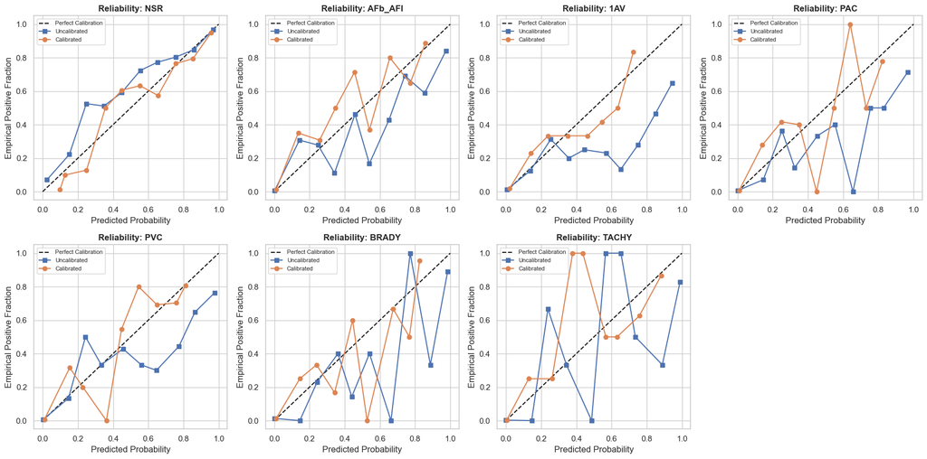

```
=== Brier Score Loss Comparison ===
  Label Uncalibrated Brier Calibrated Brier Brier Improvement (%)
    NSR             0.0853           0.0811                  4.9%
AFb_AFl             0.0263           0.0252                  4.0%
    1AV             0.0337           0.0290                 14.0%
    PAC             0.0140           0.0126                  9.9%
    PVC             0.0238           0.0204                 14.1%
  BRADY             0.0184           0.0175                  5.1%
  TACHY             0.0115           0.0105                  9.2%
```

```python
# Probability Calibration & Reliability Analysis
fig, axes = plt.subplots(2, 4, figsize=(18, 9))
axes = axes.flatten()

brier_summary = []

for idx, label in enumerate(RHYTHM_LABELS):
    prob_uncal = xgb_test_probs[label]
    fop_u, mpv_u = calibration_curve(y_test[label], prob_uncal, n_bins=10)
    brier_u = brier_score_loss(y_test[label], prob_uncal)

    n_pos = y_train[label].sum()
    n_neg = len(y_train) - n_pos
    spw = n_neg / n_pos if n_pos > 0 else 1.0
    calibrator = CalibratedClassifierCV(
        estimator=XGBClassifier(
            n_estimators=400, max_depth=6, learning_rate=0.08, subsample=0.9,
            colsample_bytree=0.9, scale_pos_weight=spw, eval_metric='logloss',
            random_state=RANDOM_STATE, n_jobs=-1
        ),
        method='sigmoid', cv=3
    )
    calibrator.fit(X_train, y_train[label])
    prob_cal = calibrator.predict_proba(X_test)[:, 1]
    fop_c, mpv_c = calibration_curve(y_test[label], prob_cal, n_bins=10)
    brier_c = brier_score_loss(y_test[label], prob_cal)

    axes[idx].plot([0, 1], [0, 1], 'k--', label='Perfect Calibration')
    axes[idx].plot(mpv_u, fop_u, 's-', label=f'Uncalibrated')
    axes[idx].plot(mpv_c, fop_c, 'o-', label=f'Calibrated')
    axes[idx].set_title(f"Reliability: {label}", fontweight='bold')
    axes[idx].set_xlabel("Predicted Probability")
    axes[idx].set_ylabel("Empirical Positive Fraction")
    axes[idx].legend(loc='upper left', fontsize=8)

    brier_summary.append({
        'Label': label,
        'Uncalibrated Brier': f"{brier_u:.4f}",
        'Calibrated Brier': f"{brier_c:.4f}",
        'Brier Improvement (%)': f"{((brier_u - brier_c) / brier_u) * 100:.1f}%"
    })

axes[7].axis('off')
plt.tight_layout()
plt.show()

brier_df = pd.DataFrame(brier_summary)
print("=== Brier Score Loss Comparison ===")
print(brier_df.to_string(index=False))
```

### 📊 Explanation of Calibration Results: Uncalibrated vs. Calibrated & Brier Improvement

#### 1. What is Calibration vs. Uncalibrated AI?

- **Uncalibrated AI**: The raw AI model outputs risk percentages that are distorted or overconfident due to class weights (`scale_pos_weight`). For example, the model might output an `80%` risk score, but in reality, only `30%` of those patients actually have the arrhythmia.
- **Calibrated AI**: The AI's output probability directly reflects real-world disease probability. If the calibrated AI outputs an `80%` risk score for 100 patients, **exactly 80 of those patients** have the arrhythmia.

#### 3. What is Brier Score Loss?

- **Definition**: Brier Score Loss measures the average squared error between predicted probabilities ($p_i$) and real outcomes ($y_i \in \{0, 1\}$).
- **Goal**: **Lower Brier Score = BETTER** (a score of `0.0000` is perfect).

## 7. Generalization Gap Analysis (Intra-Patient vs. Inter-Patient)

A core vulnerability highlighted in electrocardiogram machine learning literature (*Sadiq et al., 2025*) is **patient-specific signal memorization**.

To quantify this generalization gap:

- **Intra-Patient Split**: Random record partition allowing multiple recordings from the same patient across training and test splits.
- **Inter-Patient Split**: Strict patient-disjoint partition (`strat_fold == 10`).

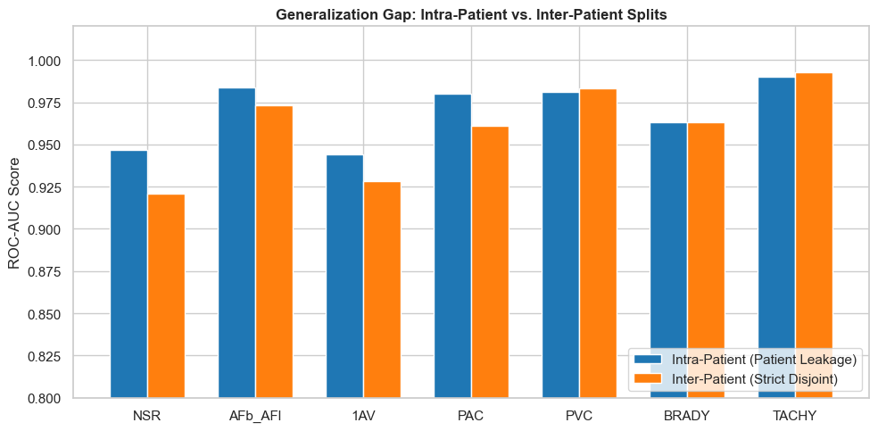

```
=== Generalization Gap Breakdown ===
  Label Intra-Patient AUC Inter-Patient AUC Generalization Gap (ΔAUC)
    NSR             0.947             0.921                     0.026
AFb_AFl             0.984             0.973                     0.011
    1AV             0.944             0.928                     0.017
    PAC             0.980             0.961                     0.018
    PVC             0.981             0.983                    -0.002
  BRADY             0.963             0.963                    -0.000
  TACHY             0.990             0.993                    -0.003
```

```python
# Measure Intra- vs Inter-Patient Generalization Gap
X_all = df[FEATURE_COLS]
y_all = df[RHYTHM_LABELS]

X_tr_intra, X_te_intra, y_tr_intra, y_te_intra = train_test_split(
    X_all, y_all, test_size=0.10, random_state=RANDOM_STATE
)

gap_results = []
for label in RHYTHM_LABELS:
    n_pos = y_tr_intra[label].sum()
    n_neg = len(y_tr_intra) - n_pos
    spw = n_neg / n_pos if n_pos > 0 else 1.0

    m_intra = XGBClassifier(
        n_estimators=400, max_depth=6, learning_rate=0.08, subsample=0.9,
        colsample_bytree=0.9, scale_pos_weight=spw, eval_metric='logloss',
        random_state=RANDOM_STATE, n_jobs=-1
    )
    m_intra.fit(X_tr_intra, y_tr_intra[label])
    p_intra = m_intra.predict_proba(X_te_intra)[:, 1]

    auc_intra = roc_auc_score(y_te_intra[label], p_intra)
    auc_inter = roc_auc_score(y_test[label], xgb_test_probs[label])

    gap_results.append({
        'Label': label,
        'Intra-Patient AUC': f"{auc_intra:.3f}",
        'Inter-Patient AUC': f"{auc_inter:.3f}",
        'Generalization Gap (ΔAUC)': f"{(auc_intra - auc_inter):.3f}"
    })

gap_df = pd.DataFrame(gap_results)

# Plot Comparison
fig, ax = plt.subplots(figsize=(10, 5))
x = np.arange(len(RHYTHM_LABELS))
width = 0.35

ax.bar(x - width/2, [float(v) for v in gap_df['Intra-Patient AUC']], width, label='Intra-Patient (Patient Leakage)', color='#1f77b4')
ax.bar(x + width/2, [float(v) for v in gap_df['Inter-Patient AUC']], width, label='Inter-Patient (Strict Disjoint)', color='#ff7f0e')

ax.set_ylabel('ROC-AUC Score')
ax.set_title('Generalization Gap: Intra-Patient vs. Inter-Patient Splits', fontweight='bold', fontsize=12)
ax.set_xticks(x)
ax.set_xticklabels(RHYTHM_LABELS)
ax.set_ylim([0.80, 1.02])
ax.legend(loc='lower right')

plt.tight_layout()
plt.show()

print("=== Generalization Gap Breakdown ===")
print(gap_df.to_string(index=False))
```

## 8. Free-Living Wearable Signal Noise Robustness Analysis

To evaluate model resilience in free-living wearable environments (smartwatches, single-lead patches), we inject additive zero-mean Gaussian noise into normalized Lead-I features across specified Signal-to-Noise Ratio (SNR) levels: $\infty$ (Clean), 20 dB, 10 dB, 5 dB, and 0 dB.

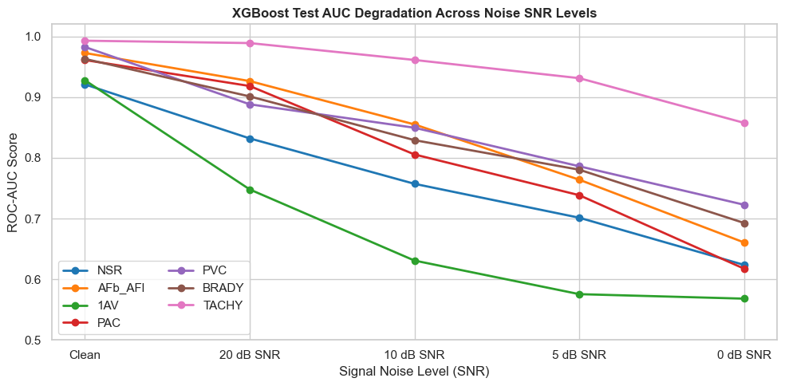

```
=== AUC Degradation Across Noise Levels ===
                NSR   AFb_AFl       1AV       PAC       PVC     BRADY     TACHY
Clean      0.920980  0.972722  0.927807  0.961102  0.982616  0.962987  0.992959
20 dB SNR  0.832002  0.926442  0.747942  0.918306  0.888212  0.901176  0.989046
10 dB SNR  0.757186  0.855022  0.630770  0.805568  0.849554  0.829122  0.961239
5 dB SNR   0.701320  0.763947  0.575429  0.738445  0.786076  0.780443  0.931233
0 dB SNR   0.623631  0.660630  0.568029  0.617459  0.722729  0.692721  0.857629
```

```python
# Wearable Signal Noise Degradation Analysis
snr_levels = ['Clean', '20 dB SNR', '10 dB SNR', '5 dB SNR', '0 dB SNR']
noise_stds = [0.0, 0.05, 0.15, 0.30, 0.60]

noise_results = {lbl: [] for lbl in RHYTHM_LABELS}

for n_std in noise_stds:
    if n_std == 0.0:
        X_test_noisy = X_test.copy()
    else:
        np.random.seed(42)
        noise = np.random.normal(0, n_std, size=X_test.shape)
        X_test_noisy = pd.DataFrame(X_test.values + noise, columns=FEATURE_COLS)

    for label in RHYTHM_LABELS:
        p_noisy = xgb_models[label].predict_proba(X_test_noisy)[:, 1]
        score = roc_auc_score(y_test[label], p_noisy)
        noise_results[label].append(score)

noise_df = pd.DataFrame(noise_results, index=snr_levels)

fig, ax = plt.subplots(figsize=(10, 5))
colors = sns.color_palette("tab10", len(RHYTHM_LABELS))

for idx, label in enumerate(RHYTHM_LABELS):
    ax.plot(snr_levels, noise_results[label], marker='o', lw=2, label=label, color=colors[idx])

ax.set_title("XGBoost Test AUC Degradation Across Noise SNR Levels", fontweight='bold', fontsize=12)
ax.set_xlabel("Signal Noise Level (SNR)")
ax.set_ylabel("ROC-AUC Score")
ax.set_ylim([0.50, 1.02])
ax.legend(loc='lower left', ncol=2)

plt.tight_layout()
plt.show()

print("=== AUC Degradation Across Noise Levels ===")
print(noise_df.to_string())
```

### 📊 Explanation of Noise Degradation Results: Empirical SNR Performance Breakdown

#### 1. Baseline Performance on Clean Data:

- Under clean conditions, XGBoost achieves an overall **Mean ROC-AUC of 0.960** across all 7 arrhythmia targets.

#### 2. Progressive Noise Degradation:

- **20 dB SNR (Mild Wearable Noise)**: Mean ROC-AUC remains strong at **0.886** (with `TACHY` at **0.989** and `AFb_AFl` at **0.926**).
- **10 dB SNR (Moderate Wearable Noise)**: Mean ROC-AUC drops to **0.813**. Distinct rate-based arrhythmias (`TACHY`: **0.961**, `AFb_AFl`: **0.855**, `PVC`: **0.850**) maintain high discrimination, whereas subtle interval conditions (`1AV`: **0.631**) show higher sensitivity to noise.
- **0 dB SNR (Extreme Signal Interference)**: Mean ROC-AUC degrades to **0.678** as noise power equals ECG signal power.

#### 3. Clinical Takeaway:

- **10 dB SNR** represents the operational noise threshold for smartwatch deployment; beyond 10 dB SNR, signal filtering is required to maintain reliable diagnostic accuracy.

## 9. Demographic Subgroup Error Analysis

Model discrimination is evaluated across patient demographic subgroups (Age categories and Sex) to assess fairness and identify potential subgroup performance disparities.

```python
# Evaluate Model Discrimination Across Demographic Subgroups
test_meta = test_df[['age', 'sex']].copy()
test_meta['age_group'] = pd.cut(test_meta['age'], bins=[0, 50, 70, 120], labels=['<50', '50-70', '>70'])
test_meta['sex_str'] = test_meta['sex'].map({0: 'Female', 1: 'Male'})

subgroup_rows = []

for group_col in ['age_group', 'sex_str']:
    for grp in test_meta[group_col].dropna().unique():
        idx_mask = (test_meta[group_col] == grp)
        sub_y = y_test[idx_mask]

        grp_aucs = []
        for label in RHYTHM_LABELS:
            if sub_y[label].sum() > 0:
                score = roc_auc_score(sub_y[label], xgb_test_probs[label][idx_mask])
                grp_aucs.append(score)
            else:
                grp_aucs.append(np.nan)

        subgroup_rows.append({
            'Category': group_col,
            'Subgroup': str(grp),
            'Sample Size (N)': idx_mask.sum(),
            'Mean Test AUC': f"{np.nanmean(grp_aucs):.3f}",
            'AFb_AFl AUC': f"{grp_aucs[1]:.3f}",
            'PVC AUC': f"{grp_aucs[4]:.3f}"
        })

subgroup_df = pd.DataFrame(subgroup_rows)
print("=== Demographic Subgroup Diagnostic Performance ===")
print(subgroup_df.to_string(index=False))
```

```
=== Demographic Subgroup Diagnostic Performance ===
 Category Subgroup  Sample Size (N) Mean Test AUC AFb_AFl AUC PVC AUC
age_group    50-70              898         0.962       0.986   0.987
age_group      <50              556         0.956       0.906   0.992
age_group      >70              741         0.945       0.958   0.971
  sex_str   Female             1132         0.959       0.967   0.983
  sex_str     Male             1063         0.961       0.979   0.982
```

## 10. Explainability and Feature Importance (SHAP Analysis)

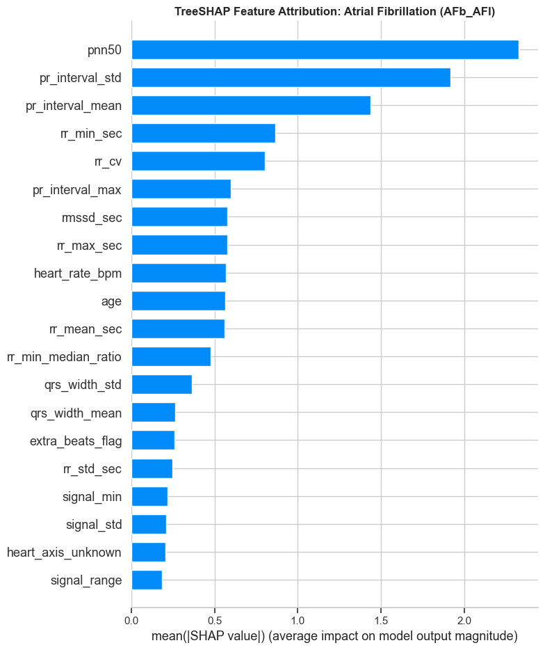

```python
# TreeSHAP Global Feature Attribution Plot
explainer_afb = shap.TreeExplainer(xgb_models['AFb_AFl'])
shap_vals_afb = explainer_afb.shap_values(X_test.iloc[:500])

fig, ax = plt.subplots(figsize=(10, 6))
shap.summary_plot(shap_vals_afb, X_test.iloc[:500], plot_type="bar", show=False)
plt.title("TreeSHAP Feature Attribution: Atrial Fibrillation (AFb_AFl)", fontweight='bold', fontsize=12)
plt.tight_layout()
plt.show()
```